# Exploratory Data Analysis on Automobile Dataset

# Import relevant libraries and define settings for plotting.

```python
import numpy as np # for numerical function
import pandas as pd # for data preprocessing
import matplotlib.pyplot as plt # for data visualization
%matplotlib inline
import seaborn as sns
import datetime
import time
```

# To Ignore Warning

```python
import warnings
warnings.filterwarnings("ignore")
```

```python
cd C:\Mehul Session\Session 27_Python Introduction\LMS FT\LMS Python\1_Python_Session_File\4_EDA\Classroom_Case Study_Automobile_EDA
```

```
C:\Mehul Session\Session 27_Python Introduction\LMS FT\LMS Python\1_Python_Session_File\4_EDA\Classroom_Case Study_Automobile_EDA
```

# Data Loading

```python
cd = ("C:/Users/Windows/Downloads")
df = pd.read_csv('EDA_Automobile_Case_.csv')
```

```python
df.head()
```

|  | symboling | normalized-losses | make | fuel-type | aspiration | num-of-doors | body-style | drive-wheels | engine-location | wheel-base | ... | engine-size | fuel-system | bore | stroke | compression-ratio | horsepower | peak-rpm | city-mpg | highway-mpg | price |
| --- | --- | --- | --- | --- | --- | --- | --- | --- | --- | --- | --- | --- | --- | --- | --- | --- | --- | --- | --- | --- | --- |
| 0 | 3 | ? | alfa-romero | gas | std | two | convertible | rwd | front | 88.6 | ... | 130 | mpfi | 3.47 | 2.68 | 9.0 | 111 | 5000 | 21 | 27 | 13495 |
| 1 | 3 | ? | alfa-romero | gas | std | two | convertible | rwd | front | 88.6 | ... | 130 | mpfi | 3.47 | 2.68 | 9.0 | 111 | 5000 | 21 | 27 | 16500 |
| 2 | 1 | ? | alfa-romero | gas | std | two | hatchback | rwd | front | 94.5 | ... | 152 | mpfi | 2.68 | 3.47 | 9.0 | 154 | 5000 | 19 | 26 | 16500 |
| 3 | 2 | 164 | audi | gas | std | four | sedan | fwd | front | 99.8 | ... | 109 | mpfi | 3.19 | 3.4 | 10.0 | 102 | 5500 | 24 | 30 | 13950 |
| 4 | 2 | 164 | audi | gas | std | four | sedan | 4wd | front | 99.4 | ... | 136 | mpfi | 3.19 | 3.4 | 8.0 | 115 | 5500 | 18 | 22 | 17450 |

5 rows × 26 columns

# Summary statistics of variable

```python
df.describe()
```

|  | symboling | wheel-base | length | width | height | curb-weight | engine-size | compression-ratio | city-mpg | highway-mpg |
| --- | --- | --- | --- | --- | --- | --- | --- | --- | --- | --- |
| count | 205.000000 | 205.000000 | 205.000000 | 205.000000 | 205.000000 | 205.000000 | 205.000000 | 205.000000 | 205.000000 | 205.000000 |
| mean | 0.834146 | 98.756585 | 174.049268 | 65.907805 | 53.724878 | 2555.565854 | 126.907317 | 10.142537 | 25.219512 | 30.751220 |
| std | 1.245307 | 6.021776 | 12.337289 | 2.145204 | 2.443522 | 520.680204 | 41.642693 | 3.972040 | 6.542142 | 6.886443 |
| min | -2.000000 | 86.600000 | 141.100000 | 60.300000 | 47.800000 | 1488.000000 | 61.000000 | 7.000000 | 13.000000 | 16.000000 |
| 25% | 0.000000 | 94.500000 | 166.300000 | 64.100000 | 52.000000 | 2145.000000 | 97.000000 | 8.600000 | 19.000000 | 25.000000 |
| 50% | 1.000000 | 97.000000 | 173.200000 | 65.500000 | 54.100000 | 2414.000000 | 120.000000 | 9.000000 | 24.000000 | 30.000000 |
| 75% | 2.000000 | 102.400000 | 183.100000 | 66.900000 | 55.500000 | 2935.000000 | 141.000000 | 9.400000 | 30.000000 | 34.000000 |
| max | 3.000000 | 120.900000 | 208.100000 | 72.300000 | 59.800000 | 4066.000000 | 326.000000 | 23.000000 | 49.000000 | 54.000000 |

```python
df.shape
```

```
(205, 26)
```

# To check datatypes of all column

```python
df.info()
```

```
<class 'pandas.core.frame.DataFrame'>
RangeIndex: 205 entries, 0 to 204
Data columns (total 26 columns):
 #   Column             Non-Null Count  Dtype
---  ------             --------------  -----
 0   symboling          205 non-null    int64
 1   normalized-losses  205 non-null    object
 2   make               205 non-null    object
 3   fuel-type          205 non-null    object
 4   aspiration         205 non-null    object
 5   num-of-doors       205 non-null    object
 6   body-style         205 non-null    object
 7   drive-wheels       205 non-null    object
 8   engine-location    205 non-null    object
 9   wheel-base         205 non-null    float64
```

[output cut: 18 more lines]

```python
df.dtypes
```

```
symboling              int64
normalized-losses     object
make                  object
fuel-type             object
aspiration            object
num-of-doors          object
body-style            object
drive-wheels          object
engine-location       object
wheel-base           float64
length               float64
width                float64
height               float64
curb-weight            int64
engine-type           object
num-of-cylinders      object
engine-size            int64
fuel-system           object
bore                  object
stroke                object
compression-ratio    float64
horsepower            object
peak-rpm              object
city-mpg               int64
highway-mpg            int64
price                 object
dtype: object
```

```python
df.shape
```

```
(205, 26)
```

```python
df['normalized-losses'].unique() # ? is missing value
#toc heck unique values of 'normalized-losses column'
```

```
array(['?', '164', '158', '192', '188', '121', '98', '81', '118', '148',
       '110', '145', '137', '101', '78', '106', '85', '107', '104', '113',
       '150', '129', '115', '93', '142', '161', '153', '125', '128',
       '122', '103', '168', '108', '194', '231', '119', '154', '74',
       '186', '83', '102', '89', '87', '77', '91', '134', '65', '197',
       '90', '94', '256', '95'], dtype=object)
```

# Data Cleaning

First Step

Data contains "?" replace it with NAN

```python
df = df.replace('?',np.NAN)
df
# we have replaced '?' by nan
```

|  | symboling | normalized-losses | make | fuel-type | aspiration | num-of-doors | body-style | drive-wheels | engine-location | wheel-base | ... | engine-size | fuel-system | bore | stroke | compression-ratio | horsepower | peak-rpm | city-mpg | highway-mpg | price |
| --- | --- | --- | --- | --- | --- | --- | --- | --- | --- | --- | --- | --- | --- | --- | --- | --- | --- | --- | --- | --- | --- |
| 0 | 3 | NaN | alfa-romero | gas | std | two | convertible | rwd | front | 88.6 | ... | 130 | mpfi | 3.47 | 2.68 | 9.0 | 111 | 5000 | 21 | 27 | 13495 |
| 1 | 3 | NaN | alfa-romero | gas | std | two | convertible | rwd | front | 88.6 | ... | 130 | mpfi | 3.47 | 2.68 | 9.0 | 111 | 5000 | 21 | 27 | 16500 |
| 2 | 1 | NaN | alfa-romero | gas | std | two | hatchback | rwd | front | 94.5 | ... | 152 | mpfi | 2.68 | 3.47 | 9.0 | 154 | 5000 | 19 | 26 | 16500 |
| 3 | 2 | 164 | audi | gas | std | four | sedan | fwd | front | 99.8 | ... | 109 | mpfi | 3.19 | 3.4 | 10.0 | 102 | 5500 | 24 | 30 | 13950 |
| 4 | 2 | 164 | audi | gas | std | four | sedan | 4wd | front | 99.4 | ... | 136 | mpfi | 3.19 | 3.4 | 8.0 | 115 | 5500 | 18 | 22 | 17450 |
| ... | ... | ... | ... | ... | ... | ... | ... | ... | ... | ... | ... | ... | ... | ... | ... | ... | ... | ... | ... | ... | ... |
| 200 | -1 | 95 | volvo | gas | std | four | sedan | rwd | front | 109.1 | ... | 141 | mpfi | 3.78 | 3.15 | 9.5 | 114 | 5400 | 23 | 28 | 16845 |
| 201 | -1 | 95 | volvo | gas | turbo | four | sedan | rwd | front | 109.1 | ... | 141 | mpfi | 3.78 | 3.15 | 8.7 | 160 | 5300 | 19 | 25 | 19045 |
| 202 | -1 | 95 | volvo | gas | std | four | sedan | rwd | front | 109.1 | ... | 173 | mpfi | 3.58 | 2.87 | 8.8 | 134 | 5500 | 18 | 23 | 21485 |
| 203 | -1 | 95 | volvo | diesel | turbo | four | sedan | rwd | front | 109.1 | ... | 145 | idi | 3.01 | 3.4 | 23.0 | 106 | 4800 | 26 | 27 | 22470 |
| 204 | -1 | 95 | volvo | gas | turbo | four | sedan | rwd | front | 109.1 | ... | 141 | mpfi | 3.78 | 3.15 | 9.5 | 114 | 5400 | 19 | 25 | 22625 |

205 rows × 26 columns

```python
df.isnull().sum()
#check total null values present
```

```
symboling             0
normalized-losses    41
make                  0
fuel-type             0
aspiration            0
num-of-doors          2
body-style            0
drive-wheels          0
engine-location       0
wheel-base            0
length                0
width                 0
height                0
curb-weight           0
engine-type           0
num-of-cylinders      0
engine-size           0
fuel-system           0
bore                  4
stroke                4
compression-ratio     0
horsepower            2
peak-rpm              2
city-mpg              0
highway-mpg           0
price                 4
dtype: int64
```

Missing Data

Missing Data

Second Step

```python
#only for your understanding query is split and written as beloiw
datas = df['normalized-losses'].loc[df['normalized-losses'] != '?']
#this is to check which row doent contail '?'\
datas.dtypes
```

[output not shown]

```python
#this is an another method of datacleaning
# Setting the missing value to mean of normalized losses and conver the datatype to integer

data = df['normalized-losses'].loc[df['normalized-losses'] != '?']

mean = data.astype(str).astype(int).mean() # converted object to int to caluculate mean

df['normalized-losses'] = df['normalized-losses'].replace('?',mean).astype(int) # '?' is replaced by mean value and stored as int
df['normalized-losses'].head()
```

```
0    122
1    122
2    122
3    164
4    164
Name: normalized-losses, dtype: int32
```

```python
df.columns
```

```
Index(['symboling', 'normalized-losses', 'make', 'fuel-type', 'aspiration',
       'num-of-doors', 'body-style', 'drive-wheels', 'engine-location',
       'wheel-base', 'length', 'width', 'height', 'curb-weight', 'engine-type',
       'num-of-cylinders', 'engine-size', 'fuel-system', 'bore', 'stroke',
       'compression-ratio', 'horsepower', 'peak-rpm', 'city-mpg',
       'highway-mpg', 'price'],
      dtype='object')
```

```python
df['normalized-losses'].unique() # '?' is replaced by mean value of 'normalized-losses'
```

```
array([122, 164, 158, 192, 188, 121,  98,  81, 118, 148, 110, 145, 137,
       101,  78, 106,  85, 107, 104, 113, 150, 129, 115,  93, 142, 161,
       153, 125, 128, 103, 168, 108, 194, 231, 119, 154,  74, 186,  83,
       102,  89,  87,  77,  91, 134,  65, 197,  90,  94, 256,  95])
```

```python
df['price'].unique() # check if any missing values in price column
```

```
array(['13495', '16500', '13950', '17450', '15250', '17710', '18920',
       '23875', '?', '16430', '16925', '20970', '21105', '24565', '30760',
       '41315', '36880', '5151', '6295', '6575', '5572', '6377', '7957',
       '6229', '6692', '7609', '8558', '8921', '12964', '6479', '6855',
       '5399', '6529', '7129', '7295', '7895', '9095', '8845', '10295',
       '12945', '10345', '6785', '11048', '32250', '35550', '36000',
       '5195', '6095', '6795', '6695', '7395', '10945', '11845', '13645',
       '15645', '8495', '10595', '10245', '10795', '11245', '18280',
       '18344', '25552', '28248', '28176', '31600', '34184', '35056',
       '40960', '45400', '16503', '5389', '6189', '6669', '7689', '9959',
       '8499', '12629', '14869', '14489', '6989', '8189', '9279', '5499',
       '7099', '6649', '6849', '7349', '7299', '7799', '7499', '7999',
       '8249', '8949', '9549', '13499', '14399', '17199', '19699',
       '18399', '11900', '13200', '12440', '13860', '15580', '16900',
       '16695', '17075', '16630', '17950', '18150', '12764', '22018',
       '32528', '34028', '37028', '9295', '9895', '11850', '12170',
       '15040', '15510', '18620', '5118', '7053', '7603', '7126', '7775',
       '9960', '9233', '11259', '7463', '10198', '8013', '11694', '5348',
       '6338', '6488', '6918', '7898', '8778', '6938', '7198', '7788',
       '7738', '8358', '9258', '8058', '8238', '9298', '9538', '8449',
       '9639', '9989', '11199', '11549', '17669', '8948', '10698', '9988',
       '10898', '11248', '16558', '15998', '15690', '15750', '7975',
       '7995', '8195', '9495', '9995', '11595', '9980', '13295', '13845',
       '12290', '12940', '13415', '15985', '16515', '18420', '18950',
       '16845', '19045', '21485', '22470', '22625'], dtype=object)
```

```python
data = df['price'].loc[df['price'] != '?']
mean = data.astype(str).astype(int).mean()
df['price'] = df['price'].replace('?',mean).astype(int)
df['price'].head()
#replaced '?' by mean value of price in price column
```

```
0    13495
1    16500
2    16500
3    13950
4    17450
Name: price, dtype: int32
```

```python
data = df['price'].loc[df['price'] != '?']
mean = data.astype(str).astype(int).mean()
df['price'] = df['price'].replace('?',mean).astype(int)
df['price'].head()
```

```
0    13495
1    16500
2    16500
3    13950
4    17450
Name: price, dtype: int32
```

```python
df['price'].unique() #check '?' is replaed by mean value or not
```

```
array([13495, 16500, 13950, 17450, 15250, 17710, 18920, 23875, 13207,
       16430, 16925, 20970, 21105, 24565, 30760, 41315, 36880,  5151,
        6295,  6575,  5572,  6377,  7957,  6229,  6692,  7609,  8558,
        8921, 12964,  6479,  6855,  5399,  6529,  7129,  7295,  7895,
        9095,  8845, 10295, 12945, 10345,  6785, 11048, 32250, 35550,
       36000,  5195,  6095,  6795,  6695,  7395, 10945, 11845, 13645,
       15645,  8495, 10595, 10245, 10795, 11245, 18280, 18344, 25552,
       28248, 28176, 31600, 34184, 35056, 40960, 45400, 16503,  5389,
        6189,  6669,  7689,  9959,  8499, 12629, 14869, 14489,  6989,
        8189,  9279,  5499,  7099,  6649,  6849,  7349,  7299,  7799,
        7499,  7999,  8249,  8949,  9549, 13499, 14399, 17199, 19699,
       18399, 11900, 13200, 12440, 13860, 15580, 16900, 16695, 17075,
       16630, 17950, 18150, 12764, 22018, 32528, 34028, 37028,  9295,
        9895, 11850, 12170, 15040, 15510, 18620,  5118,  7053,  7603,
        7126,  7775,  9960,  9233, 11259,  7463, 10198,  8013, 11694,
        5348,  6338,  6488,  6918,  7898,  8778,  6938,  7198,  7788,
        7738,  8358,  9258,  8058,  8238,  9298,  9538,  8449,  9639,
        9989, 11199, 11549, 17669,  8948, 10698,  9988, 10898, 11248,
       16558, 15998, 15690, 15750,  7975,  7995,  8195,  9495,  9995,
       11595,  9980, 13295, 13845, 12290, 12940, 13415, 15985, 16515,
       18420, 18950, 16845, 19045, 21485, 22470, 22625])
```

```python
df.columns
```

```
Index(['symboling', 'normalized-losses', 'make', 'fuel-type', 'aspiration',
       'num-of-doors', 'body-style', 'drive-wheels', 'engine-location',
       'wheel-base', 'length', 'width', 'height', 'curb-weight', 'engine-type',
       'num-of-cylinders', 'engine-size', 'fuel-system', 'bore', 'stroke',
       'compression-ratio', 'horsepower', 'peak-rpm', 'city-mpg',
       'highway-mpg', 'price'],
      dtype='object')
```

```python
data = df['horsepower'].loc[df['horsepower'] != '?']
mean = data.astype(str).astype(int).mean()
df['horsepower'] = df['horsepower'].replace('?',mean).astype(int)
df['horsepower'].head()
```

```
0    111
1    111
2    154
3    102
4    115
Name: horsepower, dtype: int32
```

```python
df['horsepower'].unique()
```

[output not shown]

```python
data = df['peak-rpm'].loc[df['peak-rpm'] != '?']
mean = data.astype(str).astype(int).mean()
df['peak-rpm'] = df['peak-rpm'].replace('?',mean).astype(int)
df['peak-rpm'].head()
```

```
0    5000
1    5000
2    5000
3    5500
4    5500
Name: peak-rpm, dtype: int32
```

```python
df.head(20)
```

|  | symboling | normalized-losses | make | fuel-type | aspiration | num-of-doors | body-style | drive-wheels | engine-location | wheel-base | ... | engine-size | fuel-system | bore | stroke | compression-ratio | horsepower | peak-rpm | city-mpg | highway-mpg | price |
| --- | --- | --- | --- | --- | --- | --- | --- | --- | --- | --- | --- | --- | --- | --- | --- | --- | --- | --- | --- | --- | --- |
| 0 | 3 | 122 | alfa-romero | gas | std | two | convertible | rwd | front | 88.6 | ... | 130 | mpfi | 3.47 | 2.68 | 9.0 | 111 | 5000 | 21 | 27 | 13495 |
| 1 | 3 | 122 | alfa-romero | gas | std | two | convertible | rwd | front | 88.6 | ... | 130 | mpfi | 3.47 | 2.68 | 9.0 | 111 | 5000 | 21 | 27 | 16500 |
| 2 | 1 | 122 | alfa-romero | gas | std | two | hatchback | rwd | front | 94.5 | ... | 152 | mpfi | 2.68 | 3.47 | 9.0 | 154 | 5000 | 19 | 26 | 16500 |
| 3 | 2 | 164 | audi | gas | std | four | sedan | fwd | front | 99.8 | ... | 109 | mpfi | 3.19 | 3.4 | 10.0 | 102 | 5500 | 24 | 30 | 13950 |
| 4 | 2 | 164 | audi | gas | std | four | sedan | 4wd | front | 99.4 | ... | 136 | mpfi | 3.19 | 3.4 | 8.0 | 115 | 5500 | 18 | 22 | 17450 |
| 5 | 2 | 122 | audi | gas | std | two | sedan | fwd | front | 99.8 | ... | 136 | mpfi | 3.19 | 3.4 | 8.5 | 110 | 5500 | 19 | 25 | 15250 |
| 6 | 1 | 158 | audi | gas | std | four | sedan | fwd | front | 105.8 | ... | 136 | mpfi | 3.19 | 3.4 | 8.5 | 110 | 5500 | 19 | 25 | 17710 |
| 7 | 1 | 122 | audi | gas | std | four | wagon | fwd | front | 105.8 | ... | 136 | mpfi | 3.19 | 3.4 | 8.5 | 110 | 5500 | 19 | 25 | 18920 |
| 8 | 1 | 158 | audi | gas | turbo | four | sedan | fwd | front | 105.8 | ... | 131 | mpfi | 3.13 | 3.4 | 8.3 | 140 | 5500 | 17 | 20 | 23875 |
| 9 | 0 | 122 | audi | gas | turbo | two | hatchback | 4wd | front | 99.5 | ... | 131 | mpfi | 3.13 | 3.4 | 7.0 | 160 | 5500 | 16 | 22 | 13207 |
| 10 | 2 | 192 | bmw | gas | std | two | sedan | rwd | front | 101.2 | ... | 108 | mpfi | 3.5 | 2.8 | 8.8 | 101 | 5800 | 23 | 29 | 16430 |
| 11 | 0 | 192 | bmw | gas | std | four | sedan | rwd | front | 101.2 | ... | 108 | mpfi | 3.5 | 2.8 | 8.8 | 101 | 5800 | 23 | 29 | 16925 |
| 12 | 0 | 188 | bmw | gas | std | two | sedan | rwd | front | 101.2 | ... | 164 | mpfi | 3.31 | 3.19 | 9.0 | 121 | 4250 | 21 | 28 | 20970 |
| 13 | 0 | 188 | bmw | gas | std | four | sedan | rwd | front | 101.2 | ... | 164 | mpfi | 3.31 | 3.19 | 9.0 | 121 | 4250 | 21 | 28 | 21105 |
| 14 | 1 | 122 | bmw | gas | std | four | sedan | rwd | front | 103.5 | ... | 164 | mpfi | 3.31 | 3.19 | 9.0 | 121 | 4250 | 20 | 25 | 24565 |
| 15 | 0 | 122 | bmw | gas | std | four | sedan | rwd | front | 103.5 | ... | 209 | mpfi | 3.62 | 3.39 | 8.0 | 182 | 5400 | 16 | 22 | 30760 |
| 16 | 0 | 122 | bmw | gas | std | two | sedan | rwd | front | 103.5 | ... | 209 | mpfi | 3.62 | 3.39 | 8.0 | 182 | 5400 | 16 | 22 | 41315 |
| 17 | 0 | 122 | bmw | gas | std | four | sedan | rwd | front | 110.0 | ... | 209 | mpfi | 3.62 | 3.39 | 8.0 | 182 | 5400 | 15 | 20 | 36880 |
| 18 | 2 | 121 | chevrolet | gas | std | two | hatchback | fwd | front | 88.4 | ... | 61 | 2bbl | 2.91 | 3.03 | 9.5 | 48 | 5100 | 47 | 53 | 5151 |
| 19 | 1 | 98 | chevrolet | gas | std | two | hatchback | fwd | front | 94.5 | ... | 90 | 2bbl | 3.03 | 3.11 | 9.6 | 70 | 5400 | 38 | 43 | 6295 |

20 rows × 26 columns

```python
# Replace the non-numeric value to null and convert the datatype

df['bore'] = pd.to_numeric(df['bore'],errors='coerce')
df.dtypes
```

```
symboling              int64
normalized-losses      int32
make                  object
fuel-type             object
aspiration            object
num-of-doors          object
body-style            object
drive-wheels          object
engine-location       object
wheel-base           float64
length               float64
width                float64
height               float64
curb-weight            int64
engine-type           object
num-of-cylinders      object
engine-size            int64
fuel-system           object
bore                 float64
stroke                object
compression-ratio    float64
horsepower            object
peak-rpm              object
city-mpg               int64
highway-mpg            int64
price                  int32
dtype: object
```

```python
# Replace the non-number value to null and convert the datatype
df['stroke'] = pd.to_numeric(df['stroke'],errors='coerce')
df.dtypes
```

[output not shown]

```python
# Convert the non-numeric data to null and convert the datatype
df['peak-rpm'] = pd.to_numeric(df['peak-rpm'],errors='coerce')
df.dtypes
```

```
symboling              int64
normalized-losses      int32
make                  object
fuel-type             object
aspiration            object
num-of-doors          object
body-style            object
drive-wheels          object
engine-location       object
wheel-base           float64
length               float64
width                float64
height               float64
curb-weight            int64
engine-type           object
num-of-cylinders      object
engine-size            int64
fuel-system           object
bore                 float64
stroke                object
compression-ratio    float64
horsepower            object
peak-rpm             float64
city-mpg               int64
highway-mpg            int64
price                  int32
dtype: object
```

```python
df.isnull().sum()
```

```
symboling            0
normalized-losses    0
make                 0
fuel-type            0
aspiration           0
num-of-doors         0
body-style           0
drive-wheels         0
engine-location      0
wheel-base           0
length               0
width                0
height               0
curb-weight          0
engine-type          0
num-of-cylinders     0
engine-size          0
fuel-system          0
bore                 4
stroke               0
compression-ratio    0
horsepower           0
peak-rpm             2
city-mpg             0
highway-mpg          0
price                0
dtype: int64
```

```python
df = df.dropna()
```

```python
df.isnull().sum()
```

```
symboling            0
normalized-losses    0
make                 0
fuel-type            0
aspiration           0
num-of-doors         0
body-style           0
drive-wheels         0
engine-location      0
wheel-base           0
length               0
width                0
height               0
curb-weight          0
engine-type          0
num-of-cylinders     0
engine-size          0
fuel-system          0
bore                 0
stroke               0
compression-ratio    0
horsepower           0
peak-rpm             0
city-mpg             0
highway-mpg          0
price                0
dtype: int64
```

```python
df.shape
```

```
(199, 26)
```

# Univariate Analysis

Univariate analysis is the simplest form of analyzing data. “Uni” means “one”, so in other words your data has only one variable. It doesn't deal with causes or relationships (unlike regression ) and it's major purpose is to describe; It takes data, summarizes that data and finds patterns in the data.

# Vehicle by make frequency diagram

by this we say that toyota make more vehical

```python
df.make.value_counts()#count no of manufacturers
df.make.value_counts().nlargest()#check top 5 make
# query has split for your understanding
```

```
toyota        32
nissan        18
mazda         17
honda         13
mitsubishi    13
Name: make, dtype: int64
```

```
<function matplotlib.pyplot.show(close=None, block=None)>
```

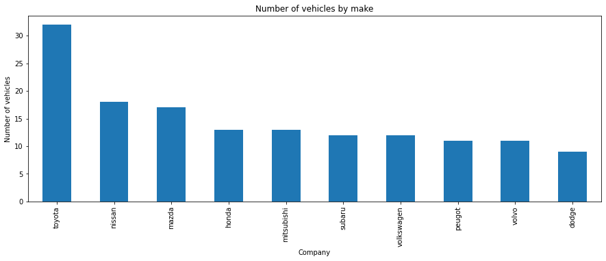

```python
df.make.value_counts().nlargest(10).plot(kind='bar', figsize=(15,5))
plt.title("Number of vehicles by make")
plt.ylabel('Number of vehicles')
plt.xlabel('Company')
plt.show
```

# symboling Histogram

from this histogram we say that mostlt symbloing values are between 0 to 2

```
array([[<AxesSubplot:title={'center':'symboling'}>]], dtype=object)
```

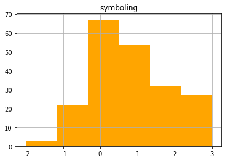

```python
df.hist(column='symboling',bins=6,color='orange')
```

# Normalized losses histogram

normalized-losses mostly range between 75 to 125

```
array([[<AxesSubplot:title={'center':'normalized-losses'}>]], dtype=object)
```

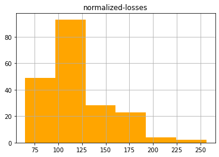

```python
df.hist(column='normalized-losses',bins=6,color='orange')
```

# histogram for all columns

```
array([[<AxesSubplot:title={'center':'symboling'}>,
        <AxesSubplot:title={'center':'normalized-losses'}>,
        <AxesSubplot:title={'center':'wheel-base'}>],
       [<AxesSubplot:title={'center':'length'}>,
        <AxesSubplot:title={'center':'width'}>,
        <AxesSubplot:title={'center':'height'}>],
       [<AxesSubplot:title={'center':'curb-weight'}>,
        <AxesSubplot:title={'center':'engine-size'}>,
        <AxesSubplot:title={'center':'compression-ratio'}>],
       [<AxesSubplot:title={'center':'city-mpg'}>,
        <AxesSubplot:title={'center':'highway-mpg'}>,
        <AxesSubplot:title={'center':'price'}>]], dtype=object)
```

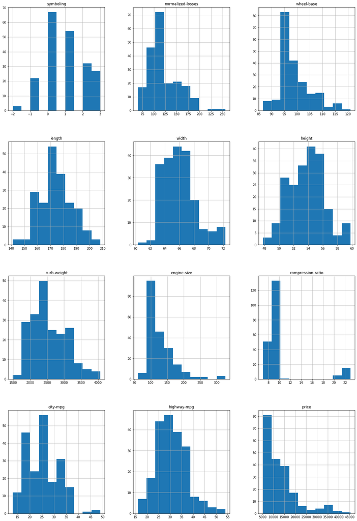

```python
df.hist(figsize=(20,30))
```

# Bar plot for Fuel type

from this we can find count of fuel-typ

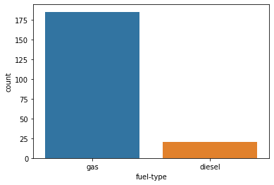

```python
sns.countplot(x="fuel-type", data=df)
```

# Bar plot for drive wheels

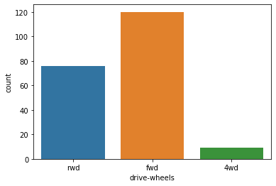

```python
sns.countplot(x="drive-wheels", data=df)
```

# Bar plot for num of doors

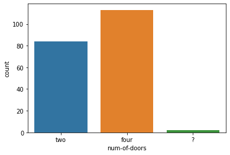

```python
sns.countplot(x="num-of-doors", data=df)
```

# find the correlation of columns with each other

```python
corr = df.corr()
corr
```

|  | symboling | normalized-losses | wheel-base | length | width | height | curb-weight | engine-size | compression-ratio | city-mpg | highway-mpg | price |
| --- | --- | --- | --- | --- | --- | --- | --- | --- | --- | --- | --- | --- |
| symboling | 1.000000 | 0.465190 | -0.531954 | -0.357612 | -0.232919 | -0.541038 | -0.227691 | -0.105790 | -0.178515 | -0.035823 | 0.034606 | -0.082201 |
| normalized-losses | 0.465190 | 1.000000 | -0.056518 | 0.019209 | 0.084195 | -0.370706 | 0.097785 | 0.110997 | -0.114525 | -0.218749 | -0.178221 | 0.133999 |
| wheel-base | -0.531954 | -0.056518 | 1.000000 | 0.874587 | 0.795144 | 0.589435 | 0.776386 | 0.569329 | 0.249786 | -0.470414 | -0.544082 | 0.583168 |
| length | -0.357612 | 0.019209 | 0.874587 | 1.000000 | 0.841118 | 0.491029 | 0.877728 | 0.683360 | 0.158414 | -0.670909 | -0.704662 | 0.682986 |
| width | -0.232919 | 0.084195 | 0.795144 | 0.841118 | 1.000000 | 0.279210 | 0.867032 | 0.735433 | 0.181129 | -0.642704 | -0.677218 | 0.728699 |
| height | -0.541038 | -0.370706 | 0.589435 | 0.491029 | 0.279210 | 1.000000 | 0.295572 | 0.067149 | 0.261214 | -0.048640 | -0.107358 | 0.134388 |
| curb-weight | -0.227691 | 0.097785 | 0.776386 | 0.877728 | 0.867032 | 0.295572 | 1.000000 | 0.850594 | 0.151362 | -0.757414 | -0.797465 | 0.820825 |
| engine-size | -0.105790 | 0.110997 | 0.569329 | 0.683360 | 0.735433 | 0.067149 | 0.850594 | 1.000000 | 0.028971 | -0.653658 | -0.677470 | 0.861752 |
| compression-ratio | -0.178515 | -0.114525 | 0.249786 | 0.158414 | 0.181129 | 0.261214 | 0.151362 | 0.028971 | 1.000000 | 0.324701 | 0.265201 | 0.070990 |
| city-mpg | -0.035823 | -0.218749 | -0.470414 | -0.670909 | -0.642704 | -0.048640 | -0.757414 | -0.653658 | 0.324701 | 1.000000 | 0.971337 | -0.667449 |
| highway-mpg | 0.034606 | -0.178221 | -0.544082 | -0.704662 | -0.677218 | -0.107358 | -0.797465 | -0.677470 | 0.265201 | 0.971337 | 1.000000 | -0.690526 |
| price | -0.082201 | 0.133999 | 0.583168 | 0.682986 | 0.728699 | 0.134388 | 0.820825 | 0.861752 | 0.070990 | -0.667449 | -0.690526 | 1.000000 |

# plot heatmap for corr

find with column are more correlated with price

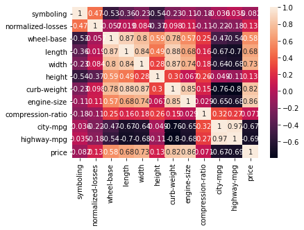

```python
sns.heatmap(corr, annot=True)
```